Cell Therapy, a Novel Remedy for Dilated Cardiomyopathy?

A Systematic Review

JOHANNES M.I.H. GHO, MD,<sup>1</sup>GIJS J.M. KUMMELING, MD,<sup>1</sup><sup>,</sup><sup>2</sup>STEFAN KOUDSTAAL, MD,<sup>1</sup><sup>,</sup><sup>2</sup>

SANNE J. JANSEN OF LORKEERS, MD,<sup>1</sup>PIETER A. DOEVENDANS, MD, PhD,<sup>1</sup><sup>,</sup><sup>2</sup>FOLKERT W. ASSELBERGS, MD, PhD,<sup>1</sup><sup>,</sup><sup>2</sup>AND

STEVEN A.J. CHAMULEAU, MD, PhD<sup>1</sup><sup>,</sup><sup>2</sup>

Utrecht, The Netherlands

ABSTRACT

Background: Dilated cardiomyopathy (DCM) is the most common form of nonischemic cardiomyopathy

worldwide and can lead to sudden cardiac death and heart failure. Despite ongoing advances made in the

treatment of DCM, improvement of outcome remains problematic. Stem cell therapy has been extensively

studied in preclinical and clinical models of ischemic heart disease, showing potential beneﬁt. DCM is

associated with a major health burden, and few studies have been performed on cell therapy for DCM.

In this systematic review we aimed to provide an overview of preclinical and clinical studies performed

on cell therapy for DCM.

Methods and Results: A systematic search, critical appraisal, and summarized outcomes are presented.

In total, 29 preclinical and 15 clinical studies were included. Methodologic quality of reported studies in

general was low based on the Centre for Evidence Based Medicine, Oxford University, criteria. A large

heterogeneity in inclusion criteria, procedural characteristics, and outcome measures was noted. The ma-

jority of studies showed a signiﬁcant increase in left ventricular ejection fraction after cell therapy during

follow-up.

Conclusions: Stem cell therapy has shown moderate but signiﬁcant effects in clinical trials for ischemic

heart disease, but it remains to be determined if we can extrapolate these results to DCM patients. There is

a need for methodologically sound studies to elucidate underlying mechanisms and translate those into

improved therapy for clinical practice. To validate safety and efﬁcacy of cell therapy for DCM, adequate

randomized (placebo) controlled trials using different strategies are mandatory. (J Cardiac Fail

2013;19:494e502)

Key Words: DCM, nonischemic cardiomyopathy, heart failure, stem cells.

Dilated cardiomyopathy (DCM) is the most common

form of nonischemic cardiomyopathy worldwide.<sup>1</sup>Esti-

mated prevalence in adults is 1/2,500 individuals, with an

incidence of 7/100,000 per year. It is deﬁned by dilation

and impaired contraction of heart muscle in the absence

of an obvious etiology such as ischemic heart disease or

valve disease. Causes are multifactorial, including genetics

as a major contributor. DCM can lead to sudden cardiac

death and heart failure, and carries a heavy burden on

health care resources owing to a high rate of hospital admis-

sion and occasional need for ventricular assist device and/or

heart transplantation. Over the past years, progress has been

made in treating DCM, but improving outcome remains

a difﬁcult goal to achieve.

Stem cell therapy for cardiac repair has been extensively

studied in acute myocardial infarction and chronic ischemic

From the <sup>1</sup>Department of Cardiology, Division Heart & Lungs, Univer-

sity Medical Center, Utrecht, The Netherlands and <sup>2</sup>Interuniversity Cardi-

ology Institute of the Netherlands (ICIN), Utrecht, The Netherlands.

Manuscript received September 16, 2012; revised manuscript received

May 9, 2013; revised manuscript accepted May 13, 2013.

Reprint requests: Johannes M.I.H. Gho, MD, Department of Cardiology,

Division Heart & Lungs, University Medical Center Utrecht, Room

E03.511, PO Box 85500, 3508 GA Utrecht, The Netherlands. Tel: þ31

88 7555555; Fax: þ31 88 7555660. E-mail: jgho@umcutrecht.nl

Funding: HGG Group (Wieringerwerf, The Netherlands) and Wijnand

M. Pon Foundation (Leusden, The Netherlands). This research forms

part of the Project P1.04 SMARTCARE of the research program of the

BioMedical Materials Institute, co-funded by the Dutch Ministry of Eco-

nomic Affairs, Agriculture, and Innovation. The ﬁnancial contribution of

the Nederlandse Hartstichting is gratefully acknowledged. Folkert W. As-

selbergs is supported by a clinical fellowship from the Netherlands Orga-

nisation for Health Research and Development (ZonMw grant 90700342).

See page 500 for disclosure information.

1071-9164/$ - see front matter

� 2013 Elsevier Inc. All rights reserved.

http://dx.doi.org/10.1016/j.cardfail.2013.05.006

494

Journal of Cardiac Failure Vol. 19 No. 7 2013

heart disease, showing potential beneﬁt.<sup>2</sup><sup>e</sup><sup>4</sup>Proposed work-

ing mechanisms include, e.g., transdifferentiation of stem

cells to cardiomyocytes, activation of intrinsic cardiac

stem cells, paracrine effects, and angiogenesis. Only

a few studies have been reported on cell therapy for

DCM, with human trials since 2006. To the best of our

knowledge, no complete overview has been reported so

far. In the present systematic review, preclinical and clinical

studies on cell therapy for DCM are reported, including val-

idity,

procedural

characteristics,

safety,

and

outcome

measures.

Methods

Data Collection and Analysis

We searched PubMed and Embase for reports of preclinical (all

years) and clinical (2006e2012) therapeutic studies on various

types of cell therapy for nonischemic DCM (search syntaxes are

provided in Supplemental Tables 1 and 2). To prevent selection

and retrieval bias, outcome was not included in the search syn-

taxes. Only English- and German-language articles were included,

and no restrictions were imposed on timing of assessment and

follow-up. Excluded were abstracts, reviews, reports from scien-

tiﬁc sessions and discussions, case reports, in vitro studies, studies

only on ischemic heart disease, pediatric studies, and articles de-

scribing study design. Retrieved studies were used for cross-

reference checking and carefully examined to exclude potentially

duplicate or overlapping data. Reviews and case reports were

available for background information. A separate search was per-

formed on ClinicalTrials.gov for ongoing trials (Supplemental

Table 3). Authors were contacted for missing data.

Assessment of Quality and Risk of Bias

For assessment of quality, risk of bias (e.g., selection or infor-

mation bias), and heterogeneity, remaining articles were consid-

ered for critical appraisal. Quality of studies were assessed in

duplicate (by G.K. and J.G.) with the use of standard forms for rel-

evance and validity according to the Centre for Evidence Based

Medicine, Oxford University, criteria.<sup>5</sup>Study design was deter-

mined, and adequate randomization (concealed allocation) or

comparable groups when not randomized, losses to follow-up,

and blinding of physician/treatment ofﬁcer or researcher were

reviewed.

Data Extraction and Management

Study characteristics and used outcome measures were summa-

rized. If necessary, data were estimated graphically or calculated

with standard deviations from available data with the use of

SPSS 17.0 (Chicago, Illinois). Two-tailed P values !.05 were

considered to be signiﬁcant.

Results

Preclinical Studies

Literature Search.

Our preclinical search yielded

1,455 unique articles (Fig. 1). After screening of title and

abstract with the use of inclusion and exclusion criteria,

29 relevant articles remained; reference checking retrieved

no new articles.

Study

Characteristics

and

Quality

Assessment.

Quality

assessment

of

included

studies

is

presented

in Supplemental Table 4. In summary, about one-half (15/

29) were conducted in a randomized fashion; 1 study (Jin

et al.) reported allocation concealment.<sup>6</sup>One study reported

blinding of the treatment ofﬁcer.<sup>7</sup>Twelve studies reported

blinding of the effect investigators for treatment. All relevant

data of the 29 studies are presented in Table 1. Two studies

used a large animal model (Hata et al: dogs; Psaltis et al:

sheep); all other studies used rodent or rabbit models.

Delivery route varied between intracoronary or intravenous

infusion, intramuscular injection, sheet graft, or surgical in-

jections, and in total 10 different stem cell types were

used. Fractional shortening, fractional area change, and ejec-

tion fraction were determined by 2-dimensional echocardi-

ography in almost all of the studies; only Psaltis et al used

magnetic resonance imaging (MRI) to determine ejection

fraction. Delta pressure/delta time and peak systolic pressure

were measured with the use of hemodynamic measurements.

Five studies reported baseline data, showing no signiﬁcant

differences in the study groups. Twenty-one out of 29 studies

had sufﬁcient and comparable proportions of follow-up, and

length of follow-up varied from 2 to 21 weeks. Lin et al, Sun

et al, and Kondoh et al (2006 and 2007) reported interim re-

sults on ejection fraction or fractional shortening. Most stud-

ies (24/29) used comparable treatment methods between

control and therapy groups. Eighteen out of 29 studies

(62%) were published in a journal with impact factor $3.00.

Efﬁcacy and Safety in Animal Models.

All animal

studies demonstrated a positive effect of stem cell therapy

on left ventricular function, of which 24 studies showed sig-

niﬁcant improvement, ranging from 3.0% to 24% on echo-

cardiographic evaluation (Table 1). In general, no safety

issues were found in these studies. Of 18 studies that as-

sessed mortality, 3 found improvement in survival.<sup>8</sup><sup>e</sup><sup>10</sup>

Ten studies found equal mortality between treatment and

control groups, other studies did not mention signiﬁcance,

and no cardiac tamponade was reported. Four studies de-

tected no arrhythmias; other studies did not mention any

occurrence of arrhythmias.<sup>10</sup><sup>e</sup><sup>13</sup>

Clinical Studies

Literature

Search.

Our

clinical

search

strategy

yielded 339 unique hits (Fig. 2). Screening of title and ab-

stract using inclusion and exclusion criteria resulted in 16

relevant articles. One relevant peer-reviewed article was

found not indexed on PubMed or Embase.<sup>14</sup>All principle

investigators from ongoing trials were contacted for up-

to-date trial results (see Ongoing Clinical Trials, below),

this resulted in 2 additional complete manuscripts.<sup>15,16</sup>Ref-

erence checking retrieved no new articles. Four articles

were excluded because of overlapping data. In total, 15 ar-

ticles were considered for critical appraisal (4 randomized

controlled trials [RCTs], 2 non-RCTs, 9 cohort studies).

Cell Therapy for Dilated Cardiomyopathy �

Gho et al

495

Authors were contacted for articles not available in full text

and missing data (8 authors responded).

Study

Characteristics

and

Quality

Assessment.

Four out of 15 studies were randomized; 2 nonRCTs used

matched control groups (Table 2). Supplemental Table 5

presents further methodologic quality of the included stud-

ies. Allocation concealment was not reported in the RCTs.

There was no patient or physician blinding performed in

these clinical studies, nor placebo used in the controlled tri-

als. Two of the controlled trials described equally treated

groups aside from the allocated treatment.<sup>17,18</sup>Losses to

follow-up were reported and adequate (#20%) in 13

out of 15 studies. All articles were published in peer-

reviewed journals, 5 (33%) of the 15 studies in a journal

with impact factor $3.00.

Sample size ranged from 3 to 131 persons and overall

follow-up duration from 3 to 60 months. Deﬁnitions used

for dilated cardiomyopathy were different between studies.

Seven studies reported excluding patients with coronary

artery disease on coronary angiography.<sup>14,16,18</sup><sup>e</sup><sup>22</sup>Only

Schannwell et al performed endomyocardial biopsy in all

patients to exclude myocarditis; Seth et al performed biop-

sies in 8/85 patients. Three studies included patients with

ischemic cardiomyopathy in a separate group; those

subgroups were excluded for this review.<sup>14,23,24</sup>For Fat-

khutdinov et al, the groups undergoing concomitant (valve)

surgery also were excluded. For cell delivery, the majority

used an intracoronary route versus a surgical procedure

with intramyocardial injections (11 vs 4). Cell type was dif-

ferent between studies: Mostly bone marrow stem cells

were used; 2 studies used fetal material. Kirillov et al had

1 group with prenatal allogenic skeletal myoblasts and 1

with prenatal mesenchymal stem cells.<sup>25</sup>

Efﬁcacy Outcomes in Clinical Trials.

Main out-

comes reported in clinical trials were left ventricular

ejection fraction (LVEF), New York Heart Association

(NYHA) functional class, quality of life (QoL), and mortal-

ity. All but 1 article mainly used 2-dimensional echocardi-

ography for determining ejection fraction; Fischer-Rasokat

et al used angiography.<sup>26</sup>Cardiac MRI was only used in

certain subgroups. Mean differences in LVEF between

baseline and ﬁnal follow-up values are presented in

Table 2 (baseline and ﬁnal LVEF values are presented in

Supplemental Table 6). LVEF values were calculated for

Arg€uero et al from available patient data; LVEF was esti-

mated in the therapy groups of Fatkhutdinov et al and the

control groups of Vrtovec et al (2011 and 2013), because

these were only graphically depicted. The majority of stud-

ies (10/15) showed a signiﬁcant increase in LVEF in the

therapy group (range 3.2% to 11%). Four studies found

no signiﬁcant difference between baseline and follow-up

in the therapy groups.<sup>17,20,24,25</sup>Kalil et al showed a signiﬁ-

cant decrease of 0.5% (P 5 .023) in mean ejection fraction

at ﬁnal follow-up (12 mo); in that study, LVEF increased in

the ﬁrst 2 months after surgical cell therapy but decreased

afterward. In the control groups, increase of mean LVEF

from baseline was less or LVEF decreased (range from

about �5% to 5.6%). The highest increase was found in

the control group of Bocchi et al, which underwent granu-

locyte colonyestimulating factor administration. Seth et al

showed a signiﬁcant difference (P ! .05) between therapy

and control groups (LVEF 5.9% vs 0.4%), and Vrtovec et al

found a signiﬁcant change in LVEF mean difference in both

studies.<sup>15,21,22</sup>

NYHA functional class improved in all 9 studies that re-

ported functional class, with signiﬁcant improvements in

more than one-half of them.<sup>14,17,19,20,27</sup>QoL was deter-

mined with the use of questionnaires and reported to be sig-

niﬁcantly improved in 6 studies.<sup>14,19</sup><sup>e</sup><sup>21,27,28</sup>Fatkhutdinov

et al found an improvement in QoL at 3 months during

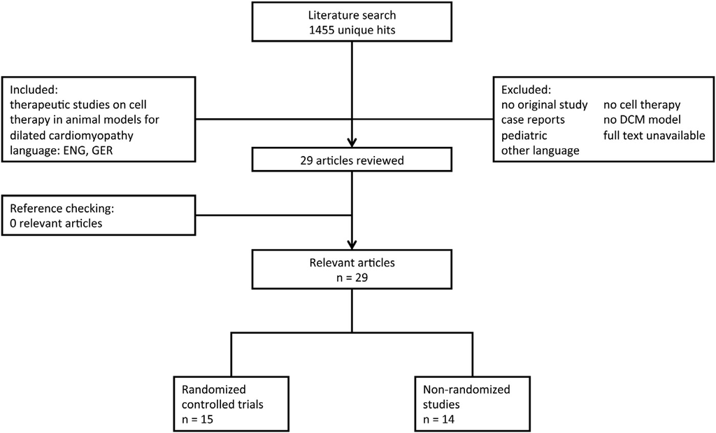

Fig. 1. Flowchart of search strategy preclinical studies. ENG, English; GER, German; DCM, dilated cardiomyopathy.

496

Journal of Cardiac Failure Vol. 19 No. 7 July 2013

follow-up, but at ﬁnal follow-up the difference was

nonsigniﬁcant.

Safety Outcomes in Clinical Trials.

Mortality was re-

ported in all studies except Bocchi et al. Comparing therapy

and control groups, Vrtovec et al (2011) found a signiﬁ-

cantly lower incidence of heart transplantation or mortality

in the therapy group (7% vs 30%; P 5 .03). At 5-year

follow-up, Vrtovec et al (2013) found a lower total mortal-

ity in patients receiving stem cell therapy compared with

control subjects (14% vs 35%; P 5 .01); occurrence of

heart transplantation did not differ between the 2 groups.

The other controlled studies found similar mortality rates.

Chin et al, Fatkhutdinov et al, and Schannwell et al found

no mortality in both groups, and of the 85 patients included

by Seth et al 12 treated patients vs 14 control subjects had

died after 3 years of follow-up. In the study by Arg€uero

et al, which mainly included patients with ischemic cardio-

myopathy, 2 patients died because of intractable arrhyth-

mias, but there was no information given of which group

either of these patients belonged to. Benetti et al, Kalil

et al, and Martino et al reported some cases with de novo

(supra)ventricular arrhythmias, quickly terminated with

chemical or electrical cardioversion. The other studies did

not show an increase in arrhythmias (only Seth et al gave

no information on occurrence of arrhythmias).

Discussion

In total, 29 preclinical and 15 clinical studies were in-

cluded in this systematic review on cell therapy for

DCM. Main ﬁndings were: 1) a low methodologic quality

in general; 2) a large heterogeneity in inclusion criteria,

procedural characteristics, and outcome measures; 3) only

2 preclinical studies involving large animals; 4) a signiﬁcant

increase in LVEF, improvement in NYHA functional class,

and QoL at follow-up after cell therapy in the majority of

clinical studies (from a total of 513 enrolled patients); 5)

several reports of potentially life-threatening arrhythmias;

and 6) no increased mortality after cell therapy.

Table 1. Preclinical Study Characteristics and Outcomes

Author

Model

n (Total/Cell

Treated)

Randomized

Follow-Up

(wk)

Cell

Type

Outcome

Measuring

Method

Measured

Effect

P Value

Large animals

Hata (2006)<sup>29</sup>

4

12/5

No

4

MB

EF

CT, abs

þ6.5%

!.05

Psaltis (2010)<sup>30</sup>

3

15/7

Yes

8

MPC

EF*

CT, abs

þ10%

!.05

Small animals

Baba (2007)<sup>11</sup>

3

67/20

No

4

ES

dP/dt

CT, rel

þ27%/�20%<sup>x</sup>

‘‘signiﬁcant’’

Chen (2006)<sup>13</sup>

3

24/8

No

4

BMMC

EF

CT, abs

þ11.1%

!.05

Chen (2010)<sup>41</sup>

3

19/6

Yes

4

BM-MSC

EF

CT, abs

þ6.4%

!.05

de Angelis (2010)<sup>8</sup>

3

160/?

No

6

CPC

EF

CT, abs

wþ24%<sup>k</sup>

!.05

Dhein (2006)<sup>7</sup>

3

38/14

Yes

4

BM-MSC

dP/dt

CT, rel

þ62%/�88%<sup>x</sup>

!.05

Garbade (2009)<sup>42</sup>

3

31/15

No

4

BMMC

FS

CT, abs

þ3%

!.01

Ishida (2004)<sup>43</sup>

3

52/18

Yes

4

BMMC

FS

CT, abs

þ4.1%

ns

Jin (2010)<sup>6</sup>

3

20/10

Yes

4

BMMC

dP/dt

CT, rel

þ35%/�32%<sup>x</sup>

!.05

Kondoh (2006)<sup>9</sup>

5

85/57

Yes

12

MB

FS

CT, abs

wþ5%<sup>k</sup>

!.05

Kondoh (2007)<sup>44</sup>

5

100/24

Yes

8

MB

FS

CT, rel

þ31%

ns

Lin (2010)<sup>45</sup>

1

40/8

Yes

13

ADMSC

EF

CT, abs

þ4.1%

!.0001

Lu (2006)<sup>46</sup>

3

35/18

Yes

4

BMMC

EF

CT, abs

þ11%

!.05

Mu (2011)<sup>47</sup>

3

120/40

Yes

4

BM-MSC

dP/dt

CT, rel

þ32%/�18%<sup>x</sup>

!.05

Nagaya (2005)<sup>48</sup>

1

30/10

No

4

MSC

FS

CT, abs

wþ11%<sup>k</sup>

!.05

Nakajima (2008)<sup>49</sup>

3

25/16

No

4

BMMC

FS

BF, abs

þ3.1%

!.05

Nomura (2006)<sup>50</sup>

2

?/15

No

4

MDPC

FS

CT, abs

wþ5%<sup>k</sup>

!.05

Ohno (2002)<sup>51</sup>

2

41/11

No

5

MB

PSP

CT, abs

wþ68%<sup>y</sup><sup>,</sup><sup>k</sup>

!.001

Pouly (2004)<sup>52</sup>

2

26/14

Yes

4

MB

FAC

BF, rel

þ24%

.019

Shabbir (2009)<sup>53</sup>

2

33/15

No

4

MSC

FS

CT, abs

wþ13%<sup>k</sup>

!.001

Singla (2012)<sup>54</sup>

3

?/?<sup>z</sup>

No

2

CM or ES

FS

CT, abs

þ5%

!.05

Sun (2009)<sup>55</sup>

1

28/10

Yes

13

BMMC

EF

CT, abs

þ5.5%

.0002

Suzuki (2001)<sup>56</sup>

3

16/8

No

4

MB

dP/dt

CT, rel

þ20%/�20%<sup>x</sup>

.01

Tezuka (2008)<sup>12</sup>

2

?/?

No

15

MB

dP/dt

CT, rel

þ15%/�37%<sup>x</sup>

!.05

Werner (2005)<sup>57</sup>

1

25/12

No

4

EPC

FS

BF, rel

þ15%

Unknown

Yamada (2008)<sup>10</sup>

6

118/8

Yes

21

ES

FS

BF, abs

þ12.5%

!.05

Zhang (2005)<sup>58</sup>

3

42/18

Yes

4

BMMC

FS

CT, abs

þ3.8%

ns

Zhou (2007)<sup>59</sup>

3

20/10

Yes

12

BMMC

EF

CT, abs

þ0.1%

ns

Disease model: 1) porcine myosin þ Freund adjuvant; 2) genetic d-sarcoglycan deﬁciency; 3) doxorubicin or adriamycin; 4) pacing-induced DCM (230/

min); 5) BIO TO-2 hamsters; 6) Kir 6.2 knockout þ aortic constriction. Cell type: ADMSC, adipose-derived stem cells; BM(M)C, bone marrow (mononu-

clear) cells; CM, conditioned medium; CPC, cardiac progenitor cells; EPC, endothelial progenitor cells; ES, embryonic stem cells; MB, myoblasts; MDPC,

myosphere-derived progenitor cell; MPC, mesenchymal precursor cells; MSC, mesenchymal stem cells. Measuring method: BF, baseline vs follow-up; CT,

control vs therapy; abs, absolute difference; rel, relative difference. EF, ejection fraction; dP/dt, delta pressure/delta time; FS, fractional shortening; FAC,

fractional area change; PSP, peak systolic pressure; ns, nonsigniﬁcant.

*Determined with the use of MRI.

yAverage difference in PSP.

zSingla used 6e8 animals per group; 1 group underwent cell therapy.

xMeasured effect of dP/dt (maximum/minimum).

kEstimated effect based on graphics.

Cell Therapy for Dilated Cardiomyopathy �

Gho et al

497

From ‘‘Bench to Bedside’’

Study validity in preclinical studies showed a lack in

methodologic quality, about one-half were randomized,

and only 1 study used concealed allocation. No blinding

was performed in the majority of the included articles.

We found a large heterogeneity among studies in disease

models, therapy, and end points. It is therefore difﬁcult to

combine the results to infer a stronger conclusion on stem

cell therapy. However, all studies showed a positive effect

on left ventricular function, mostly by attenuation of dete-

rioration, also shown in the studies reporting interim results

(Fig. 3). Largest improvement was found by de Angelis

et al using cardiac progenitor cells on doxorubicin-

induced cardiomyopathy in rats. Contractility also was

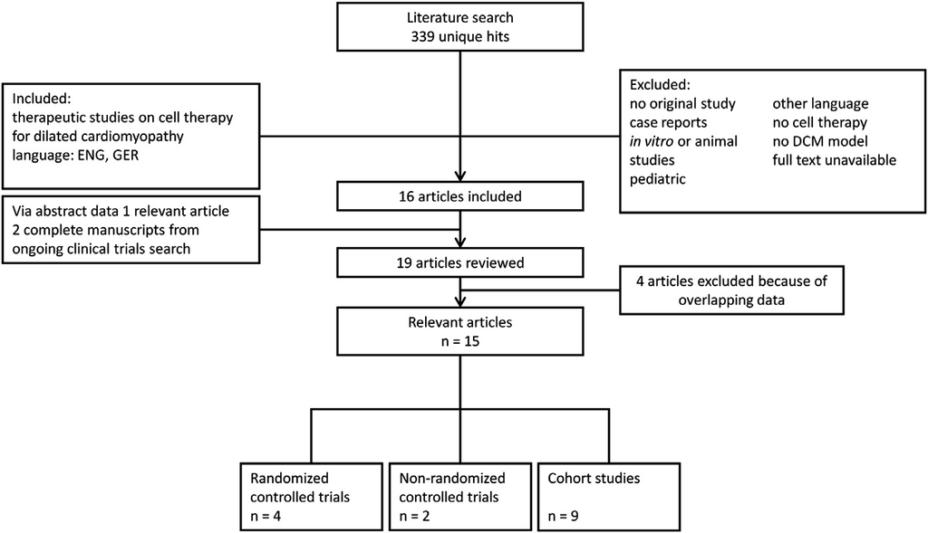

Fig. 2. Flowchart of search strategy clinical trials. Abbreviations as in Fig. 1.

Table 2. Clinical Study Characteristics and Outcomes

Author (year)

Group

n (total)

Follow-Up (mo)

Delivery Route

Cell Type

EF Mean Difference (%)

P Value

RCTs

Bocchi (2010)<sup>27</sup>

Therapy

14 (23)*

615y

IC

BMC

þ8.8

.016

Control

8

þ5.6

.04

Seth (2010)<sup>21</sup>

Therapy

44 (85)

36

IC

BMC

þ5.9

!.05

Control

41

þ0.4

ns

Vrtovec (2011)<sup>22</sup>

Therapy

28 (61)<sup>z</sup>

12

IC

Autologous CD34þ

þ4.6

.03

Control

27

w�2<sup>k</sup>

Unknown

Vrtovec (2013)<sup>15</sup>

Therapy

55 (131)<sup>z</sup>

60

IC

Autologous CD34þ

þ5.7

.02

Control

55

w�3<sup>k</sup>

Unknown

Non-RCTs

Fatkhutdinov (2010)<sup>17</sup>

Therapy

6 (14)

12

IC

Allogenic MSC

w0<sup>k</sup>

ns

Control

8

w�5<sup>k</sup>

ns

Schannwell (2008)<sup>18</sup>

Therapy

10 (20)

3

IC

BMC-MN

þ9

!.01

Control

10

0

ns

Cohort

Arg€uero (2006)<sup>23</sup>

3 (5)<sup>x</sup>

Unknown

Surgical

Autologous CD34þ

þ8.7

.0059

Benetti (2010)<sup>19</sup>

10

40

Surgical

HFDSC

þ8.2

.005

Chin (2011)<sup>24</sup>

3

12

IC

BM-MSC

þ15.1

ns

Fischer-Rasokat (2009)<sup>26</sup>

33

12

IC

BMC

þ3.2

!.001

Kalil (2008)<sup>28</sup>

9

12

Surgical

BMC

�0.5

.023

Kirillov (2007)<sup>25</sup>

Group 1

9

6

IC

Prenatal ASM

þ2

ns

Group 2

7

Prenatal MSC

þ1.6

ns

Martino (2010)<sup>20</sup>

24

6

IC

BMC-MN

þ1.2

ns

Ruengsakulrach (2011)<sup>14</sup>

52

613<sup>y</sup>

Surgical

ACP

þ4.4

.03

Su�arez de Lezo (2013)<sup>16</sup>

27

12

IC

BMMC

þ11

.001

RCT, randomized controlled trial; Cohort, cohort study. Cell type: ACP, angiogenic cell precursors; ASM, allogenic skeletal myoblasts; BM(M)C, bone

marrow (mononuclear) cells; HFDSC, human fetal-derived stem cells; MSC, mesenchymal stem cell; MN, mononuclear; EF, ejection fraction; G-CSF, gran-

ulocyte colonyestimulating factor; IC, intracoronary; ns, nonsigniﬁcant.

*Randomized to G-CSF administration (14) or G-CSF associated to BMSC intracoronary infusion (8).

yBocchi et al mean 468 6 374 days (up to 1,190 days), Ruengsakulrach et al mean 409.7 6 352.4 days.

zAll patients received G-CSF before randomization; 6 (2011) and 21 (2013) patients were excluded in this phase.

x3/5 patients included in preliminary report, outcomes calculated.

kEstimated difference based on graphics.

498

Journal of Cardiac Failure Vol. 19 No. 7 July 2013

signiﬁcantly and positively inﬂuenced. Comparing stem

celletreated animals with control animals, 10 out of 29

studies reported equal mortality or sometimes even im-

provement of survival. No conclusion can be drawn regard-

ing arrhythmias, which was reported in only 4 studies.

Main proposed mechanisms of stem cell effects on DCM

include reduction of ﬁbrosis and angiogenesis by direct (cell

engraftment, regenerative transdifferentiation) and paracrine

support.<sup>29,30</sup>No additional ﬁbrosis is seen following therapy;

sometimes even attenuation is seen. It remains possible that

publication bias and methods of measurement attributed an

overestimation and positive image of stem cell therapy for

DCM. Left ventricular hemodynamics and MRI are more ob-

jective than 2-dimensional echocardiography in measuring

left ventricular function. An optimal animal model for DCM

is still lacking. Overall, stem cell therapy seems to be feasible

and effective in preclinical models; however, large animal

studies are scarce in the transition from bench to bedside.

Back from ‘‘Bedside to Bench’’

Quality Assessment, Safety, and Efﬁcacy in Clinical

Trials.

In 2006 consensus of the Task Force of the Euro-

pean Society of Cardiology (ESC) addressed the possible

need for autologous cell therapy in DCM.<sup>31</sup>In the same

year, the ﬁrst human clinical trials were reported, and in

summary they were predominantly pioneering trials assess-

ing safety and efﬁcacy. There was a lack in methodologic

quality, because mainly nonrandomized trials were per-

formed. Lack of allocation concealment, placebo effect,

or procedural characteristics, such as delivery techniques

and growth factor administration, could have inﬂuenced

the outcome. Especially studies with a short follow-up

period should be interpreted with caution regarding whether

the positive outcome would be sustained over a longer pe-

riod. We noticed a large heterogeneity in inclusion criteria,

procedural characteristics, and outcome measures.

These studies showed no increase in mortality in the cell

therapy groups. There were several reports on potentially

life-threatening arrhythmias.<sup>19,20,23,28</sup>Furthermore, a case re-

port (n 5 2) describing a pilot trial on cell therapy in DCM

showed severe complications after intracoronary balloon in-

ﬂation, with hypotension and ventricular arrhythmias in one

patient and severe spasm with hypotension requiring bailout

stenting in another; therefore, that trial was prematurely ter-

minated.<sup>32</sup>So these procedures carry an arrhythmic risk,

which should be assessed in future studies.

There seems to be a positive effect of cell therapy for

DCM on LVEF, NYHA functional class and QoL, although

this should be veriﬁed in large randomized trials. Also,

more studies are needed for determining optimal delivery

route and cell type for cardiac repair. Outcomes should

be given as absolute differences to more accurately estimate

actual treatment effect. This would result in clear indica-

tions for cell therapy in nonischemic cardiomyopathy, pref-

erable above random patient selection. Using multiple

‘‘rising’’ imaging modalities, such as MRI, 3-dimensional

echocardiography, and single-photon emission computed

tomography, would provide more accuracy for determining

outcomes.<sup>33</sup>Although we would prefer MRI to determine

outcome measures, certain heart failure patients would be

ineligible because of implanted devices, such as implant-

able cardioverter-deﬁbrillator and cardiac resynchroniza-

tion

therapy.

Besides

clinically

relevant

LVEF

measurements, detailed measuring of local cardiac function

can provide information about local changes induced by

cardiac

regenerative

therapy.<sup>34</sup>

Combined

global

and

regional myocardial function measurements are recommen-

ded to assess the effects of cardiac regenerative therapy.

Elucidating Underlying Mechanisms.

Current evi-

dence reveals controversy regarding stem cell transdifferen-

tiation to cardiomyocytes contributing to cardiac functional

gain, which has led to investigating paracrine mechanisms

for repair.<sup>35,36</sup>In contrast to cell therapy for ischemic cardio-

myopathy, where angiogenesis plays an important role, in

DCM heart muscle disease and myocardial dysfunction pres-

ent a different background. However, marked vascular de-

rangements and impaired vasculogenic and angiogenic

responses have also been reported in idiopathic DCM.<sup>37</sup>Pro-

posed underlying working mechanisms should be differenti-

ated between ischemic cardiomyopathy and DCM, e.g., by

elucidating these issues in preclinical studies. Findings from

clinical studies should also be clariﬁed in collaboration

with preclinical research. As progress is being made for

DCM in unraveling underlying genetic mutations and molec-

ular mechanisms (e.g., calcium metabolism), these could be

used in future for tailored cell and/or gene therapy.<sup>38,39</sup>

Ongoing Clinical Trials

Several clinical trials on cell therapy for DCM are under-

way (Table 3). Nine trials were found on ClinicalTrials.gov

(Supplemental Table 3). All principle investigators were

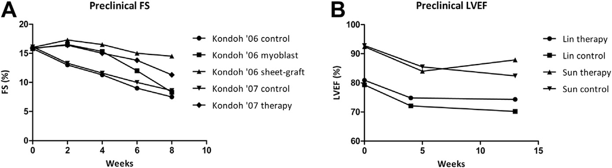

Fig. 3. Preclinical studies reporting interim results on (A) fractional shortening (FS) or (B) left ventricular ejection fraction (LVEF).

Cell Therapy for Dilated Cardiomyopathy �

Gho et al

499

contacted for up-to-date trial results, which resulted in 2

complete manuscripts that were added to the clinical stud-

ies section. Most studies are randomized; only 1 study is

double-blind and placebo controlled with another control

group receiving granulocyte colonyestimulating factor.

Delivery routes are intracoronary, intramyocardial, or trans-

endocardial (mainly using the NOGA XP/Myostar injection

catheter system), and different cell types are used. Primary

outcome measures are assessing safety or LVEF.

Study Limitations

The large heterogeneity in study characteristics of in-

cluded reports could have inﬂuenced outcome; therefore,

we examined reasons for heterogeneity with the use of stan-

dardized criteria. Differences between animal DCM models

and human disease carry limitations when translating from

bench to bedside. Publication bias can not be ruled out, be-

cause smaller studies are prone to publication bias. Esti-

mates of effect are vulnerable to confounding by lack of

randomization. Only reported outcomes were included, be-

cause we did not have access to complete individual data

and accordingly, mean values are provided; authors were

contacted in case of missing data.

Future Implications

Only a few studies on cell therapy for DCM have been

performed and methodologic quality in general was low.

The majority of studies show a signiﬁcant positive effect

on LVEF. There is a need for methodologically sound

(pre)clinical studies to elucidate underlying mechanisms

and to translate these into improved therapy for clinical

practice. Clearly described uniform deﬁnitions for inclusion

should be used in future studies, e.g., derived from the ESC

classiﬁcation.<sup>40</sup>Adequately randomized (placebo) con-

trolled trials are mandatory to validate safety and efﬁcacy

of cell therapy for DCM, preferably with long-term

follow-up. These studies should focus on occurrence of ar-

rhythmias, mortality, optimal cell delivery techniques, and

cell type with the use of different modern image modalities.

Stem cell therapy has shown moderate but signiﬁcant ef-

fects in clinical trials for ischemic heart disease comprising

almost 2,000 patients.<sup>4</sup>It still remains to be determined if

we can extrapolate these results to DCM patients. Neverthe-

less, this exciting ﬁeld of research has shown promising re-

sults so far and warrants continuation of ongoing study

programs.

Disclosures

None.

Supplementary Data

Supplementary data related to this article can be found at

http://dx.doi.org/10.1016/j.cardfail.2013.05.006.

References

1. Jefferies JL, Towbin JA. Dilated cardiomyopathy. Lancet 2010;375:

752e62.

2. van der Spoel TI, Jansen of Lorkeers SJ, Agostoni P, van Belle E,

Gyongyosi M, Sluijter JP, et al. Human relevance of pre-clinical stud-

ies in stem cell therapy: systematic review and meta-analysis of large

animal models of ischaemic heart disease. Cardiovasc Res 2011;91:

649e58.

3. Strauer BE, Steinhoff G. 10 years of intracoronary and intramyocar-

dial bone marrow stem cell therapy of the heart: from the methodo-

logical origin to clinical practice. J Am Coll Cardiol 2011;58:

1095e104.

4. Zimmet H, Porapakkham P, Porapakkham P, Sata Y, Haas SJ,

Itescu S, et al. Short- and long-term outcomes of intracoronary and

endogenously mobilized bone marrow stem cells in the treatment

Table 3. Ongoing Clinical Trials on Cell Therapy for Dilated Cardiomyopathy

Identiﬁer

(Short Name)

Design

Blinding

Delivery

Route

Cell Type

Primary Outcome

Measure (modality)

Estimated

Completion

Date

Status

NCT01302171

(REGENERATE-DCM)

RCT

Double-blind

IC

BM-MNC vs placebo/G-CSF

LVEF (MRI)

Dec 2012

Recruiting

NCT01350310

(NOGA-DCM)

RCT

Single-blind

IC vs IM

CD34þ

LVEF (echocardiography)

Mar 2013

Recruiting

NCT00765518

(IMPACT-DCM)

RCT

Open-label

IM

CRC

Safety

Feb 2012

Completed

NCT01392625

(POSEIDON-DCM)

RCT

Open-label

TE

Autologous vs allogenic MSC

Safety

Jul 2015

Recruiting

NCT01020968

RCT

Open-label

TE

CRC

Safety

Feb 2012

Active, not

recruiting

NCT00333827

(MiHeart)

RCT

Double-blind

IC

BMC

LVEF

Feb 2009

Unknown

NCT00721045

(Revascor)

RCT

Single-blind

TE

MPC

Safety

Jul 2011

Unknown

RCT, randomized controlled trial; IC, intracoronary; IM, intramyocardial; TE, transendocardial; BM-MNC, bone marrow mononuclear cells; G-CSF, gran-

ulocyte colonyestimulating factor; CRC, cardiac repair cells; BMC, bone marrow cells; MPC, mesynchymal precursor cells; MSC, mesenchymal stem cells;

LVEF, left ventricular ejection fraction; MRI, magnetic resonance imaging.

500

Journal of Cardiac Failure Vol. 19 No. 7 July 2013

of ST-segment elevation myocardial infarction: a meta-analysis of

randomized control trials. Eur J Heart Fail 2012;14:91e105.

5. Centre for Evidence Based Medicine, Oxford University. EBM

Tools. Critical appraisal sheets. Available at: http://www.cebm.net/

index.aspx?o51157. Accessed February 14, 2012.

6. Jin B, Luo XP, Ni HC, Li Y, Shi HM. Cardiac matrix remodeling fol-

lowing intracoronary cell transplantation in dilated cardiomyopathic

rabbits. Mol Biol Rep 2010;37:3037e42.

7. Dhein S, Garbade J, Rouabah D, Abraham G, Ungemach FR,

Schneider K, et al. Effects of autologous bone marrow stem cell

transplantation on beta-adrenoceptor density and electrical activation

pattern in a rabbit model of nonischemic heart failure. J Cardiothorac

Surg 2006;1:17.

8. De Angelis A, Piegari E, Cappetta D, Marino L, Filippelli A,

Berrino L, et al. Anthracycline cardiomyopathy is mediated by deple-

tion of the cardiac stem cell pool and is rescued by restoration of pro-

genitor cell function. Circulation 2010;121:276e92.

9. Kondoh H, Sawa Y, Miyagawa S, Sakakida-Kitagawa S, Memon IA,

Kawaguchi N, et al. Longer preservation of cardiac performance by

sheet-shaped myoblast implantation in dilated cardiomyopathic ham-

sters. Cardiovasc Res 2006;69:466e75.

10. Yamada S, Nelson TJ, Crespo-Diaz RJ, Perez-Terzic C, Liu XK,

Miki T, et al. Embryonic stem cell therapy of heart failure in genetic

cardiomyopathy. Stem Cells 2008;26:2644e53.

11. Baba S, Heike T, Yoshimoto M, Umeda K, Doi H, Iwasa T, et al.

Flk1<sup>þ</sup>cardiac stem/progenitor cells derived from embryonic stem

cells improve cardiac function in a dilated cardiomyopathy mouse

model. Cardiovasc Res 2007;76:119e31.

12. Tezuka A, Kawada T, Nakazawa M, Masui F, Konno S, Nitta S, et al.

Which skeletal myoblasts and how to be transplanted for cardiac re-

pair? Biochemical and biophysical research communications 2008;

369:270e6.

13. Chen M, Fan ZC, Liu XJ, Deng JL, Yang Q, Huang DJ. Cell trans-

plantation with a catheter-based approach: an efﬁcient method for

the treatment of heart failure with multiple lesions. Cell Prolif

2006;39:471e7.

14. Ruengsakulrach P, Visudharom K, Chaothawee L, Belkin M. Periph-

eral blood stem cell for cardiomyopathy. Bangkok Med J 2011;2:

19e29.

15. Vrtovec B, Poglajen G, Lezaic L, Sever M, Domanovic D, Cernelc P,

et al. Effects of intracoronary CD34þ stem cell transplantation in

nonischemic dilated cardiomyopathy patients: 5-year follow-up.

Circ Res 2013;112:165e73.

16. Su�arez de Lezo J, Herrera C, Romero M, Pan M, Su�arez de Lezo J,

Carmona MD, et al. Functional improvement in patients with dilated

cardiomyopathy after the intracoronary infusion of autologous bone

marrow mononuclear cells. Rev Esp Cardiol 2013;66:450e7.

17. Fatkhutdinov T, d’Yachkov AV, Koroteyev AV, Goldstein DV,

Bochkov NP. Safety and efﬁciency of transplantation of allogenic

multipotent stromal cells in surgical treatment of dilatated cardiomy-

opathy. Bull Exp Biol Med 2010;149:119e24.

18. Schannwell CM, K€ostering M, Zeus T, Brehm M, Erdmann G,

Fleissner T, et al. [Humane autologe intrakoronare stammzelltrans-

plantation zur myokardregeneration bei dilatativer cardiomyopathie

(NYHA stadium II-IV)]. The D€usseldorf Autologous Bone Marrow

Cells in Dilated Cardiomyopathy Trial. ABCD Trial. J Kardiol

2008;15:23e30. German.

19. Benetti F, Penherrera E, Maldonado T, Vera YD, Subramanian V,

Geffner L. Direct myocardial implantation of human fetal stem cells

in heart failure patients: long-term results. Heart Surg Forum 2010;

13:E31e5.

20. Martino HF, Oliveira PS, Souza FC, Costa PC, Assuncao ESE,

Villela R, et al. A safety and feasibility study of cell therapy in di-

lated cardiomyopathy. Braz J Med Biol Res 2010;43:989e95.

21. Seth S, Bhargava B, Narang R, Ray R, Mohanty S, Gulati G, et al.

The ABCD (Autologous Bone Marrow Cells in Dilated Cardiomyop-

athy) trial: a long-term follow-up study. J Am Coll Cardiol 2010;55:

1643e4.

22. Vrtovec B, Poglajen G, Sever M, Lezaic L, Domanovic D, Cernelc P,

et al. Effects of intracoronary stem cell transplantation in patients

with dilated cardiomyopathy. J Card Fail 2011;17:272e81.

23. Arguero

R,

Careaga-Reyna

G,

Castano-Guerra

R,

Garrido-

Garduno MH, Magana-Serrano JA, de Jesus NamboeLucio M.

Cellular autotransplantation for ischemic and idiopathic dilated car-

diomyopathy. Preliminary report. Arch Med Res 2006;37:1010e4.

24. Chin SP, Poey AC, Wong CY, Chang SK, Tan CS, Ng MT, et al. In-

tramyocardial and intracoronary autologous bone marrowederived

mesenchymal stromal cell treatment in chronic severe dilated cardio-

myopathy. Cytotherapy 2011;13:814e21.

25. Kirillov

AM,

Fatkhudinov

T,

Dyachkov

AV,

Koroteev

AV,

Goldshtein DV, Bochkov NP. Transplantation of allogenic cells in

the therapy of patients with dilated cardiomyopathy. Bull Exp Biol

Med 2007;144:635e9.

26. Fischer-Rasokat U, Assmus B, Seeger FH, Honold J, Leistner D,

Fichtlscherer S, et al. A pilot trial to assess potential effects of selec-

tive intracoronary bone marrow-derived progenitor cell infusion in

patients with nonischemic dilated cardiomyopathy: ﬁnal 1-year re-

sults of the transplantation of progenitor cells and functional regen-

eration enhancement pilot trial in patients with nonischemic dilated

cardiomyopathy. Circ Heart Fail 2009;2:417e23.

27. Bocchi EA, Bacal F, Guimaraes G, Mendroni A, Mocelin A, Filho AE,

et al. Granulocyte-colony stimulating factor or granulocyte-colony

stimulating factor associated to stem cell intracoronary infusion effects

in non ischemic refractory heart failure. Int J Cardiol 2010;138:94e7.

28. Kalil RA, Ott D, Sant’Anna R, Dias E, Marques-Pereira JP, Delgado-

Canedo A, et al. Autologous transplantation of bone marrow mono-

nuclear stem cells by mini-thoracotomy in dilated cardiomyopathy:

technique and early results. Sao Paulo Med J 2008;126:75e81.

29. Hata H, Matsumiya G, Miyagawa S, Kondoh H, Kawaguchi N,

Matsuura N, et al. Grafted skeletal myoblast sheets attenuate myocar-

dial remodeling in pacing-induced canine heart failure model. J Thor-

ac Cardiovasc Surg 2006;132:918e24.

30. Psaltis PJ, Carbone A, Nelson AJ, Lau DH, Jantzen T, Manavis J,

et al. Reparative effects of allogeneic mesenchymal precursor cells

delivered transendocardially in experimental nonischemic cardiomy-

opathy. JACC Cardiovasc interv 2010;3:974e83.

31. Bartunek

J,

Dimmeler

S,

Drexler

H,

Fernandez-Aviles

Galinanes M, Janssens S, et al. The consensus of the Task Force of<sup>F,</sup>

the European Society of Cardiology concerning the clinical investi-

gation of the use of autologous adult stem cells for repair of the heart.

Eur Heart J 2006;27:1338e40.

32. Widimsky P, Penicka M. Complications after intracoronary stem cell

transplantation in idiopathic dilated cardiomyopathy. Int J Cardiol

2006;111:178e9.

33. Marwick TH, Raman SV, Carrio I, Bax JJ. Recent developments in

heart failure imaging. JACC Cardiovasc Imaging 2010;3:429e39.

34. van Slochteren FJ, Teske AJ, van der Spoel TI, Koudstaal S,

Doevendans PA, Sluijter JP, et al. Advanced measurement techniques

of regional myocardial function to assess the effects of cardiac regen-

erative therapy in different models of ischaemic cardiomyopathy. Eur

Heart J Cardiovasc Imaging 2012;13:808e18.

35. Segers VF, Lee RT. Stem-cell therapy for cardiac disease. Nature

2008;451:937e42.

36. Maxeiner H, Krehbiehl N, Muller A, Woitasky N, Akinturk H,

Muller M, et al. New insights into paracrine mechanisms of human

cardiac progenitor cells. Eur J Heart Fail 2010;12:730e7.

37. Roura S, Bayes-Genis A. Vascular dysfunction in idiopathic dilated

cardiomyopathy. Nat Rev Cardiol 2009;6:590e8.

38. Jessup M, Greenberg B, Mancini D, Cappola T, Pauly DF, Jaski B,

et al. Calcium Upregulation by Percutaneous Administration of

Gene Therapy in Cardiac Disease (CUPID): a phase 2 trial of intra-

coronary gene therapy of sarcoplasmic reticulum Ca<sup>2</sup><sup>þ</sup>-ATPase in pa-

tients with advanced heart failure. Circulation 2011;124:304e13.

39. Sun N, Yazawa M, Liu J, Han L, Sanchez-Freire V, Abilez OJ, et al.

Patient-speciﬁc induced pluripotent stem cells as a model for familial

dilated cardiomyopathy. Sci Transl Med 2012;4:130ra47.

Cell Therapy for Dilated Cardiomyopathy �

Gho et al

501

40. Elliott P, Andersson B, Arbustini E, Bilinska Z, Cecchi F, Charron P,

et al. Classiﬁcation of the cardiomyopathies: a position statement

from the European Society of Cardiology Working Group on Myo-

cardial and Pericardial Diseases. Eur Heart J 2008;29:270e6.

41. Chen Y, Liu W, Li W, Gao C. Autologous bone marrow mesenchy-

mal cell transplantation improves left ventricular function in a rabbit

model of dilated cardiomyopathy. Exp Mol Pathol 2010;88:311e5.

42. Garbade J, Dhein S, Lipinski C, Aupperle H, Arsalan M, Borger MA,

et al. Bone marrowederived stem cells attenuate impaired contractil-

ity and enhance capillary density in a rabbit model of Doxorubicin-

induced failing hearts. J Card Surg 2009;24:591e9.

43. Ishida M, Tomita S, Nakatani T, Fukuhara S, Hamamoto M,

Nagaya N, et al. Bone marrow mononuclear cell transplantation

had beneﬁcial effects on doxorubicin-induced cardiomyopathy. J

Heart Lung Transplant 2004;23:436e45.

44. Kondoh H, Sawa Y, Fukushima N, Matsumiya G, Miyagawa S, Kita-

gawa-Sakakida S, et al. Combined strategy using myoblasts and he-

patocyte growth factor in dilated cardiomyopathic hamsters. Ann

Thorac Surg 2007;84:134e41.

45. Lin YC, Leu S, Sun CK, Yen CH, Kao YH, Chang LT, et al. Early

combined treatment with sildenaﬁl and adipose-derived mesenchy-

mal stem cells preserves heart function in rat dilated cardiomyopathy.

J Transl Med 2010;8:88.

46. Lu C, Arai M, Misao Y, Chen X, Wang N, Onogi H, et al. Autologous

bone marrow cell transplantation improves left ventricular function

in rabbit hearts with cardiomyopathy via myocardial regeneration-

unrelated mechanisms. Heart Vessels 2006;21:180e7.

47. Mu Y, Cao G, Zeng Q, Li Y. Transplantation of induced bone marrow

mesenchymal stem cells improves the cardiac function of rabbits

with dilated cardiomyopathy via upregulation of vascular endothelial

growth factor and its receptors. Exp Biol Med (Maywood) 2011;236:

1100e7.

48. Nagaya N, Kangawa K, Itoh T, Iwase T, Murakami S, Miyahara Y,

et al. Transplantation of mesenchymal stem cells improves cardiac

function in a rat model of dilated cardiomyopathy. Circulation

2005;112:1128e35.

49. Nakajima H, Sakakibara Y, Tambara K, Marui A, Yoshimoto M,

Premaratne GU, et al. Delivery route in bone marrow cell

transplantation should be optimized according to the etiology of heart

disease. Circ J 2008;72:1528e35.

50. Nomura T, Ashihara E, Tateishi K, Asada S, Ueyama T, Takahashi T,

et al. Skeletal myosphere-derived progenitor cell transplantation pro-

motes neovascularization in delta-sarcoglycan knockdown cardiomy-

opathy. Biochem Biophys Res Commun 2007;352:668e74.

51. Ohno N, Fedak PW, Weisel RD, Mickle DA, Fujii T, Li RK. Trans-

plantation of cryopreserved muscle cells in dilated cardiomyopathy:

effects on left ventricular geometry and function. J Thorac Cardio-

vasc Surg 2003;126:1537e48.

52. Pouly J, Hagege AA, Vilquin JT, Bissery A, Rouche A, Bruneval P, et al.

Does the functional efﬁcacy of skeletal myoblast transplantation extend

to nonischemic cardiomyopathy? Circulation 2004;110:1626e31.

53. Shabbir A, Zisa D, Suzuki G, Lee T. Heart failure therapy mediated

by the trophic activities of bone marrow mesenchymal stem cells:

a noninvasive therapeutic regimen. Am J Physiol Heart Circ Physiol

2009;296:H1888e97.

54. Singla DK, Ahmed A, Singla R, Yan B. Embryonic stem cells im-

prove cardiac function in doxorubicin-induced cardiomyopathy me-

diated through multiple mechanisms. Cell Transplant 2012;21:

1919e30.

55. Sun CK, Chang LT, Sheu JJ, Chiang CH, Lee FY, Wu CJ, et al. Bone

marrowederived mononuclear cell therapy alleviates left ventricular

remodeling and improves heart function in rat-dilated cardiomyopa-

thy. Crit Care Med 2009;37:1197e205.

56. Suzuki K, Murtuza B, Suzuki N, Smolenski RT, Yacoub MH. Intra-

coronary infusion of skeletal myoblasts improves cardiac function in

doxorubicin-induced heart failure. Circulation 2001;104:I213e7.

57. Werner L, Deutsch V, Barshack I, Miller H, Keren G, George J.

Transfer of endothelial progenitor cells improves myocardial perfor-

mance in rats with dilated cardiomyopathy induced following exper-

imental myocarditis. J Mol Cell Cardiol 2005;39:691e7.

58. Zhang J, Li GS, Li GC, Zhou Q, Li WQ, Xu HX. Autologous mes-

enchymal stem cells transplantation in adriamycin-induced cardio-

myopathy. Chin Med J (Engl) 2005;118:73e6.

59. Zhou C, Yang C, Xiao S, Fei H. Feasibility of bone marrow stromal

cells autologous transplantation for dilated cardiomyopathy. J Huaz-

hong Univ Sci Technolog Med Sci 2007;27:75e8.

502

Journal of Cardiac Failure Vol. 19 No. 7 July 2013